# Insurance Analysis with R

Hamed Rezaei

2026-05-11

# Syfte

Syftet med denna analys är att undersöka vilka faktorer som påverkar försäkringskostnader.

# Metod

Jag har arbetat i R där jag först läste in och undersökte datat. Sedan städade jag datat och skapade nya variabler som bmi_cat och age_group.

- Datasamling och översikt
- Datastädning
- Skapande av nya variabler:(bmi_cat, age_group)
- Bmi_cat : delar in BMI i risknivåer för enklare analys.
- age_group: grupperar ålder för att förenkla tolkning och se skillnader.
- Visualisering
- Regression (model_1 och model_2)

## Data förståelse

```r
source("../scripts/Analysis.R")
```

```
## spc_tbl_ [1,100 × 14] (S3: spec_tbl_df/tbl_df/tbl/data.frame)
##  $ customer_id      : chr [1:1100] "C100000" "C100001" "C100002" "C100003" ...
##  $ age              : num [1:1100] 48 40 50 62 39 39 63 52 36 49 ...
##  $ sex              : chr [1:1100] "female" "male" "female" "male" ...
##  $ region           : chr [1:1100] "east" "west" "south" "north" ...
##  $ bmi              : num [1:1100] 24.8 29.5 18.3 25.5 27.3 23.3 23.9 24.8 28.6 26.9 ...
##  $ children         : num [1:1100] 0 1 2 5 2 4 3 2 0 2 ...
##  $ smoker           : chr [1:1100] "no" "no" "no" "yes" ...
##  $ chronic_condition: chr [1:1100] "no" "no" "no" "no" ...
##  $ exercise_level   : chr [1:1100] "high" "medium" "high" "medium" ...
##  $ plan_type        : chr [1:1100] "basic" "basic" "standard" "basic" ...
##  $ prior_accidents  : num [1:1100] 0 0 0 0 0 0 0 0 0 1 ...
##  $ prior_claims     : num [1:1100] 0 1 0 0 1 0 0 0 1 0 ...
##  $ annual_checkups  : num [1:1100] 1 4 3 NA 0 2 1 2 3 2 ...
##  $ charges          : num [1:1100] 6439 8274 5191 14500 6534 ...
##  - attr(*, "spec")=
##   .. cols(
##   ..   customer_id = col_character(),
##   ..   age = col_double(),
##   ..   sex = col_character(),
##   ..   region = col_character(),
##   ..   bmi = col_double(),
##   ..   children = col_double(),
##   ..   smoker = col_character(),
##   ..   chronic_condition = col_character(),
##   ..   exercise_level = col_character(),
##   ..   plan_type = col_character(),
##   ..   prior_accidents = col_double(),
##   ..   prior_claims = col_double(),
##   ..   annual_checkups = col_double(),
##   ..   charges = col_double()
##   .. )
##  - attr(*, "problems")=<externalptr>
## Rows: 1,100
## Columns: 14
## $ customer_id       <chr> "C100000", "C100001", "C100002", "C100003", "C100004…
## $ age               <dbl> 48, 40, 50, 62, 39, 39, 63, 52, 36, 49, 36, 36, 45, …
## $ sex               <chr> "female", "male", "female", "male", "female", "femal…
## $ region            <chr> "east", "west", "south", "north", "east", "west", "e…
## $ bmi               <dbl> 24.8, 29.5, 18.3, 25.5, 27.3, 23.3, 23.9, 24.8, 28.6…
```

[output cut: 10 more lines]

```
## Columns: 14
## $ customer_id       <int> 100000, 100001, 100002, 100003, 100004, 100005, 1000…
## $ age               <int> 48, 40, 50, 62, 39, 39, 63, 52, 36, 49, 36, 36, 45, …
## $ sex               <fct> female, male, female, male, female, female, female, …
## $ region            <fct> east, west, south, north, east, west, east, north, e…
## $ bmi               <dbl> 24.8, 29.5, 18.3, 25.5, 27.3, 23.3, 23.9, 24.8, 28.6…
## $ children          <int> 0, 1, 2, 5, 2, 4, 3, 2, 0, 2, 2, 2, 1, 1, 1, 1, 0, 3…
## $ smoker            <fct> no, no, no, yes, no, no, no, no, no, yes, no, no, no…
## $ chronic_condition <chr> "no", "no", "no", "no", "no", "no", "no", "no", "yes…
## $ exercise_level    <chr> "high", "medium", "high", "medium", "medium", "high"…
## $ plan_type         <chr> "basic", "basic", "standard", "basic", "basic", "sta…
## $ prior_accidents   <dbl> 0, 0, 0, 0, 0, 0, 0, 0, 0, 1, 0, 1, 0, 0, 0, 0, 0, 0…
## $ prior_claims      <dbl> 0, 1, 0, 0, 1, 0, 0, 0, 1, 0, 0, 1, 0, 1, 3, 0, 0, 0…
## $ annual_checkups   <dbl> 1, 4, 3, NA, 0, 2, 1, 2, 3, 2, 3, 3, 4, 4, 2, 1, 2, …
## $ charges           <dbl> 6439.10, 8274.06, 5190.99, 14500.35, 6534.40, 8026.3…
```

[figure not shown]

[figure not shown]

```r
colSums(is.na(df))
```

```
##       customer_id               age               sex            region
##                 0                 0                 0                 0
##               bmi          children            smoker chronic_condition
##                28                 0                 0                 0
##    exercise_level         plan_type   prior_accidents      prior_claims
##                22                 0                 0                 0
##   annual_checkups           charges           bmi_cat         age_group
##                20                 0                 0                 0
```

# Resultat

## Översikt av data

```r
summary_stats
```

```
## # A tibble: 1 × 3
##   mean_cost median_cost max_cost
##       <dbl>       <dbl>    <dbl>
## 1    10060.       9124.   32559.
```

- Medelvärde = genomsnittlig kostnad
- Median = typisk kostnad
- Max = högsta kostnad

## Distribution av kostnader

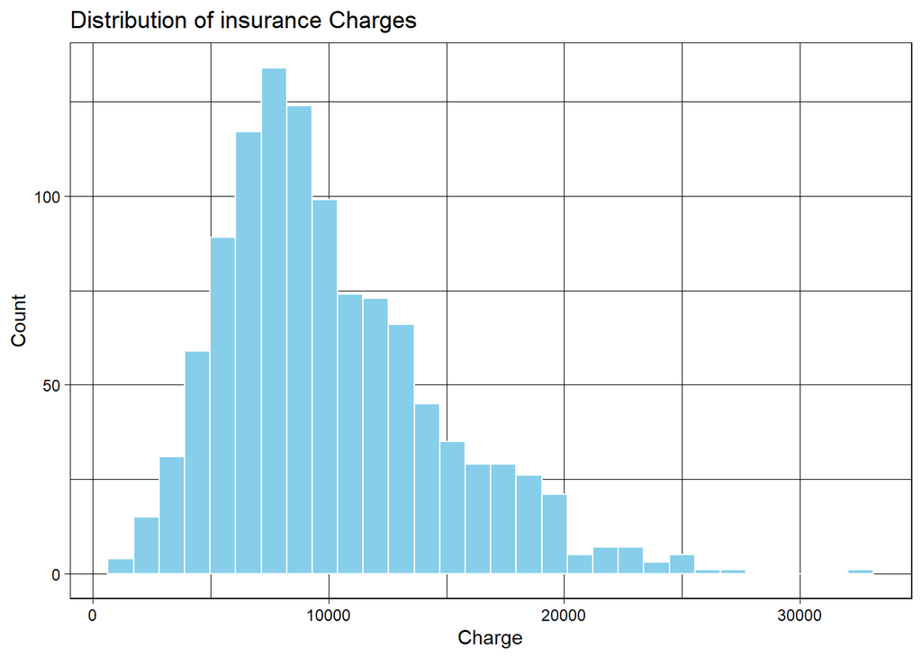

```r
plots$hist
```

- Fördelningen är högerskev
- De flesta har låga kostnader
- Några har mycket höga kostnader

## Rökning och kostnader

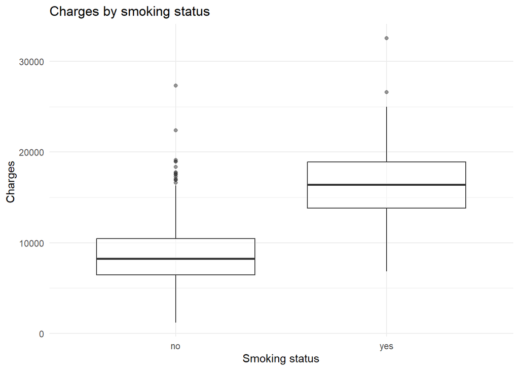

```r
plots$smoker
```

- Rökare har mycket högre kostnader
- Tydlig skillnad mellan grupper

## Ålder och kostnader

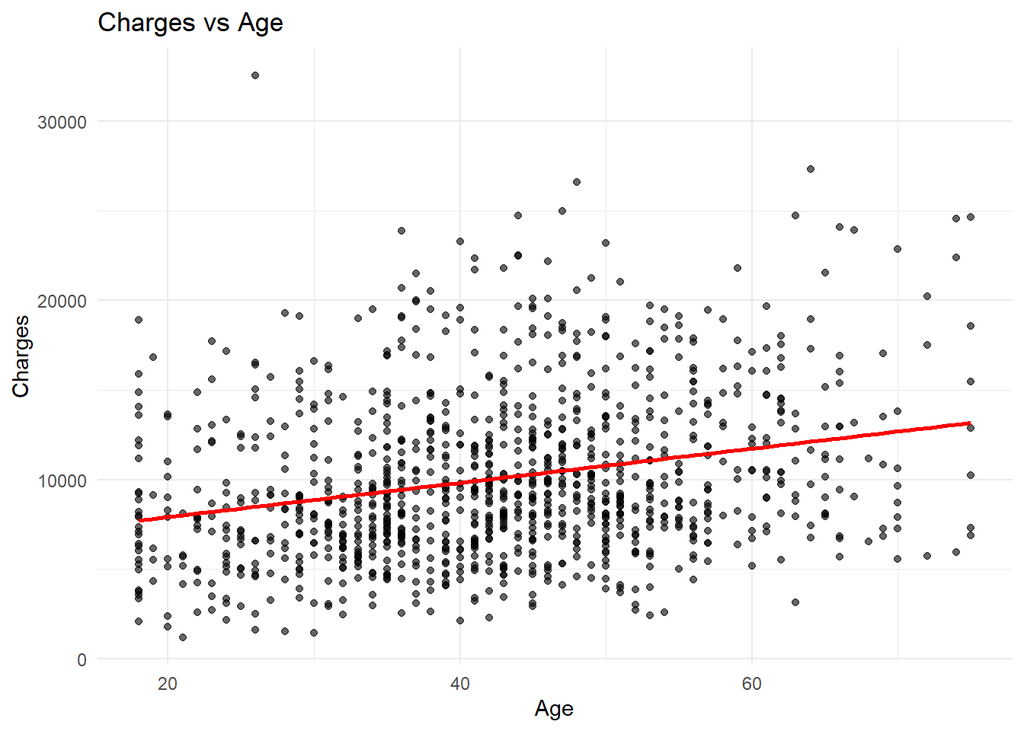

```r
plots$age
```

- Kostnader ökar med ålder
- Positivt samband

## BMI och kostnader

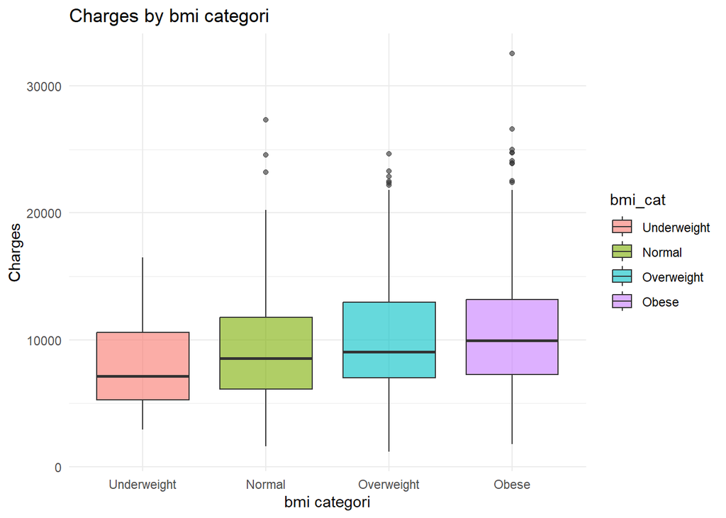

```r
plots$bmi
```

- Högre BMI > högre kostnader
- Gruppen “Obese” sticker ut

# Regressionsanalys

Jag skapade två modeller.

Model 1: innehöll grundvariabler (age, bmi, smoker, children)

Model 2: innehöll även nya variabler (bmi_cat och age_group)

## Modeljämförelse

```r
model_comparison
```

```
## # A tibble: 2 × 4
##   model                                 r_squared adjusted_r_squared residual_se
##   <chr>                                     <dbl>              <dbl>       <dbl>
## 1 Model 1: age + bmi + smoker + childr…     0.554              0.553       3081.
## 2 Model 2: smoker + children + bmi_cat…     0.543              0.539       3126.
```

## Tolkning

- Rökning har störst effekt
- Ålder påverkar kostnader
- BMI påverkar kostnader
- Model 2 visar gruppskillnader

## Regressionsdiagnostik

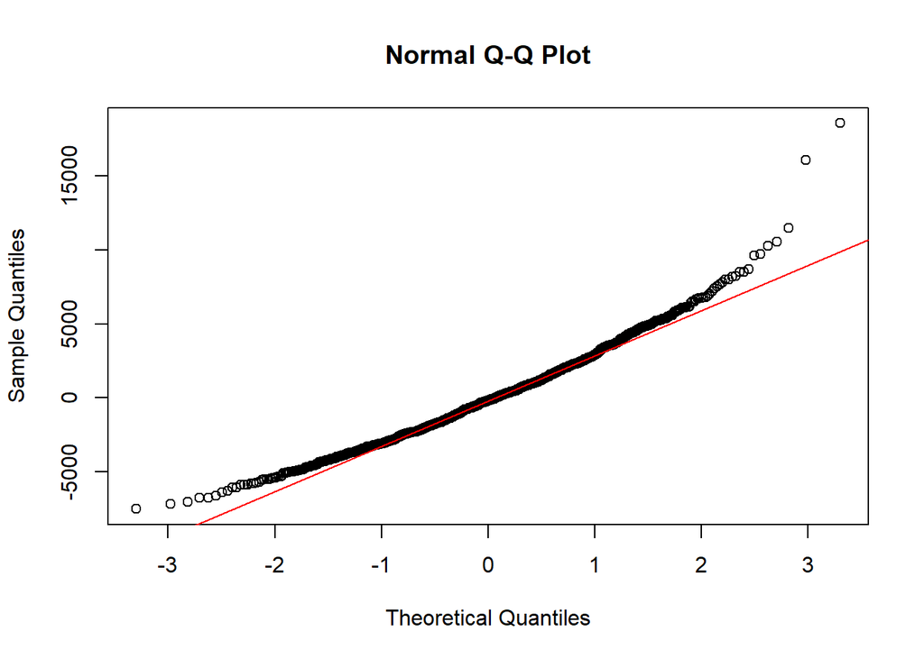

```r
qqnorm(resid(model_2))
qqline(resid(model_2), col = "red")
```

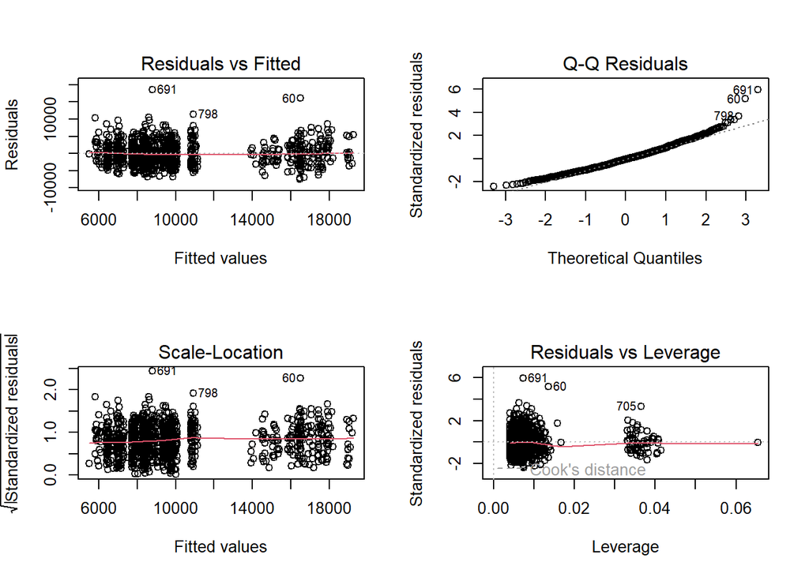

```r
par(mfrow = c(2,2))
plot(model_2)
```

```r
par(mfrow = c(1,1))
```

Residualdiagrammet visar ett relativt slumpmässigt mönster, vilket tyder på att antagandet om linjäritet är rimligt uppfyllt.

Scale-Location-plottens spridning visar viss variation, vilket kan tyda på svag heteroskedasticitet.

Några observationer har hög leverage och kan påverka modellen mer än övriga datapunkter.

# Slutsats

Analysen visar att livsstil har stor påverkan på försäkringskostnader, särskilt rökning. Regressionsmodellen kan användas som ett stöd, men den förklarar inte allt.

Modelljämförelsen baseras på samma dataset (df_model) för att säkerställa en rättvis jämförelse.

## Reflektion över modellen

- Regressionsmodellerna gav användbara insikter om vilka faktorer som påverkar försäkringskostnader. Särskilt rökning visade en stark påverkan på kostnaderna i båda modellerna.
- Diagnostiken visade samtidigt att modellen har vissa begränsningar och att resultaten därför bör tolkas med viss försiktighet. Trots detta ger modellen en tydlig översikt över viktiga samband i datan.

# Begränsningar

- Modellen inkluderar inte alla variabler som kan påverka försäkringskostnader.
- Variabler som exercise_level, plan_type och chronic_condition användes inte i modellen.
- Modellen är linjär, vilket innebär att vissa mer komplexa samband kan ha missats.
- Resultaten visar samband men bevisar inte kausalitet.